# Regression with correlated errors

## Topics

Deterministic vs stochastic elements

Regression with autocorrelated errors

Regression with temporal random effects

## A very simple model

Consider this simple model, consisting of a mean \(\mu\) plus error

\[ y_i = \mu + e_i ~ \text{with} ~ e_i \sim \text{N}(0,\sigma^2) \]

## A very simple model

The right-hand side of the equation is composed of *deterministic* and *stochastic* pieces

\[ y_i = \underbrace{\mu}_{\text{deterministic}} + \underbrace{e_i}_{\text{stochastic}} \]

## A very simple model

Sometime these pieces are referred to as *fixed* and *random*

\[ y_i = \underbrace{\mu}_{\text{fixed}} + \underbrace{e_i}_{\text{random}} \]

## A simple time series model

Consider a simple model with a mean \(\mu\) plus white noise

\[ y_t = \mu + e_t ~ \text{with} ~ e_t \sim \text{N}(0,\sigma^2) \]

## Time series model with covariates

We can expand the deterministic part of the model, as before with linear regression

\[ y_t = \underbrace{\alpha + \beta x_t}_{\text{mean}} + e_t ~ \text{with} ~ e_t \sim \text{N}(0,\sigma^2) \]

so

\[ y_t \sim \text{N}(\alpha + \beta x_t,\sigma^2) \]

## Example of linear model

[figure not shown]

## Model residuals

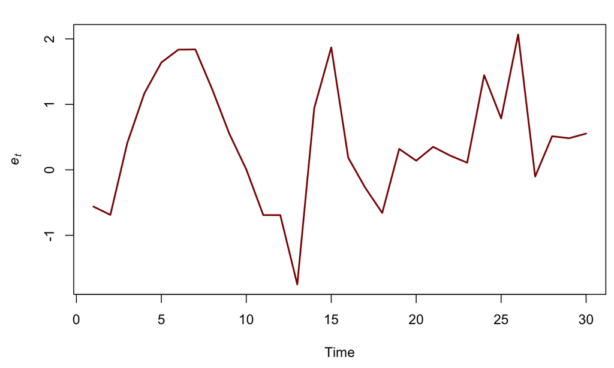

These do *not* look like white noise!